# Blood-based Gene Expression Biomarkers for Alzheimer’s Disease Diagnosis

LASSO regularisation and cross-validation using GEO dataset GSE63060

2026-03-22

## 1. Background

Alzheimer’s Disease (AD) is the leading cause of dementia worldwide. Early diagnosis is critical but currently relies on expensive or invasive methods (PET, CSF biomarkers). Identifying blood-based gene expression signatures offers a non-invasive, scalable alternative.

This analysis uses **GSE63060**, a publicly available dataset from the NCBI Gene Expression Omnibus (GEO) containing whole-blood gene expression profiles from AD patients and healthy controls. The goal is to apply **LASSO regularisation** with **10-fold cross-validation** to identify a minimal, robust set of gene biomarkers that can distinguish AD cases from controls.

**Key methods used:**

- `GEOquery` to download public data directly from NCBI GEO
- `glmnet` for LASSO and Elastic Net regularisation
- `caret` for cross-validated model evaluation
- Multiple comparison correction (FDR / Benjamini-Hochberg)

## 2. Data acquisition

Dataset: **GSE63060** - Platform: Illumina HumanHT-12 V3.0 expression beadchip - Samples: whole blood from AD patients and age-matched controls - Reference: Lunnon et al. (2012), *Molecular Psychiatry*

```r
# Install Bioconductor if needed:
# if (!requireNamespace("BiocManager", quietly = TRUE)) install.packages("BiocManager")
# BiocManager::install("GEOquery")

library(GEOquery)
library(limma)
library(glmnet)
library(ggplot2)
library(dplyr)
library(tidyr)
library(pheatmap)
library(caret)

set.seed(42)
```

```r
# Download GSE63060 directly from GEO (requires internet connection)
gse <- getGEO("GSE63060", GSEMatrix = TRUE, AnnotGPL = TRUE)
gse <- gse[[1]]

cat("Dataset dimensions:", dim(exprs(gse)), "\n")
```

```
## Dataset dimensions: 38323 329
```

```r
cat("Number of samples:", ncol(exprs(gse)), "\n")
```

```
## Number of samples: 329
```

```r
cat("Number of probes:", nrow(exprs(gse)), "\n")
```

```
## Number of probes: 38323
```

## 3. Data preprocessing

```r
expr_matrix <- exprs(gse)
pheno       <- pData(gse)

# stayus
raw_labels <- pheno[["status:ch1"]]
cat("Valores únicos en status:ch1:\n")
```

```
## Valores únicos en status:ch1:
```

```r
print(table(raw_labels))
```

```
## raw_labels
##  AD CTL MCI
## 145 104  80
```

```r
# AD vs Control (not MCI)
labels <- case_when(
  raw_labels == "AD"  ~ "AD",
  raw_labels == "CTL" ~ "Control",
  TRUE ~ NA_character_
)

keep        <- !is.na(labels)
expr_matrix <- expr_matrix[, keep]
labels      <- factor(labels[keep], levels = c("Control", "AD"))

cat("\nFinal sample counts:\n")
```

```
##
## Final sample counts:
```

```r
print(table(labels))
```

```
## labels
## Control      AD
##     104     145
```

```r
# Force conversion to plain base R numeric matrix
expr_matrix <- matrix(
  as.numeric(expr_matrix),
  nrow = nrow(expr_matrix),
  ncol = ncol(expr_matrix),
  dimnames = list(rownames(expr_matrix), colnames(expr_matrix))
)

# Remove probes with any NA values
expr_matrix <- expr_matrix[complete.cases(expr_matrix), ]
cat("Probes after removing NAs:", nrow(expr_matrix), "\n")
```

```
## Probes after removing NAs: 38323
```

```r
# Log2-transform only if values suggest raw intensities
if (max(expr_matrix, na.rm = TRUE) > 100) {
  expr_matrix <- log2(expr_matrix + 1)
  cat("Log2 transformation applied.\n")
} else {
  cat("Data appears already log-scaled. No transformation applied.\n")
}
```

```
## Data appears already log-scaled. No transformation applied.
```

```r
expr_norm <- expr_matrix

# Remove probes with very low variance (uninformative)
probe_var  <- apply(expr_norm, 1, var, na.rm = TRUE)
var_thresh <- quantile(probe_var, 0.25, na.rm = TRUE)
expr_filt  <- expr_norm[!is.na(probe_var) & probe_var > var_thresh, ]

cat("Probes after variance filtering:", nrow(expr_filt), "\n")
```

```
## Probes after variance filtering: 28742
```

```r
cat("Dimensions:", dim(expr_filt), "\n")
```

```
## Dimensions: 28742 249
```

## 4. Exploratory analysis

```r
n_show   <- min(30, ncol(expr_filt))
idx      <- sample(seq_len(ncol(expr_filt)), n_show)
n_probes <- min(50, nrow(expr_filt))

mat_sub    <- expr_filt[seq_len(n_probes), idx]
expr_vals  <- as.numeric(as.vector(mat_sub))
sample_ids <- as.character(rep(colnames(mat_sub), each = nrow(mat_sub)))

df_box <- data.frame(
  Expression = expr_vals,
  Sample     = sample_ids,
  stringsAsFactors = FALSE
)

print(head(df_box))  # debug: to confirm columns
```

```
##   Expression     Sample
## 1  14.947126 GSM1539167
## 2  12.182364 GSM1539167
## 3   7.708854 GSM1539167
## 4  11.036719 GSM1539167
## 5   7.946496 GSM1539167
## 6   7.491584 GSM1539167
```

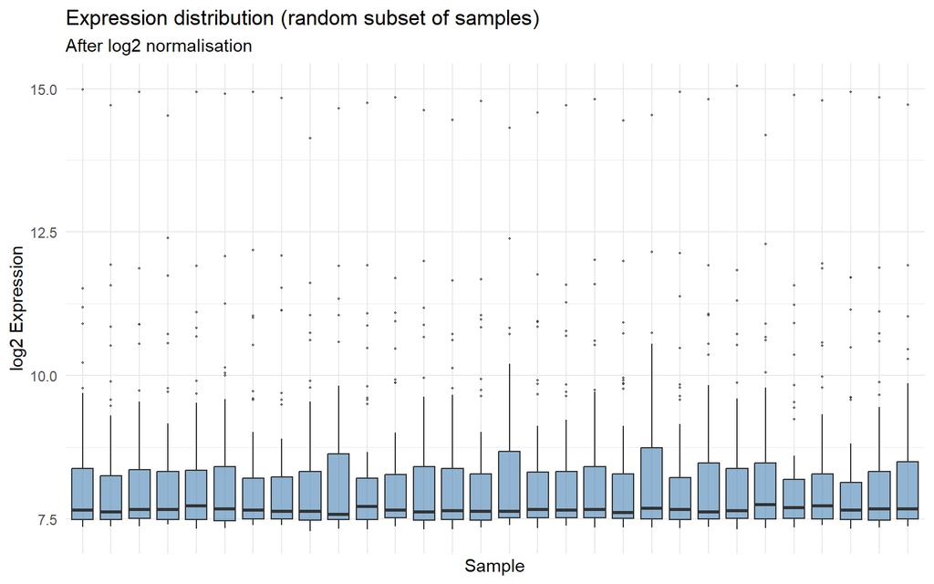

Expression distribution per sample

```r
ggplot(data = df_box, mapping = aes(x = Sample, y = Expression)) +
  geom_boxplot(outlier.size = 0.3, fill = "steelblue", alpha = 0.6) +
  theme_minimal(base_size = 11) +
  theme(axis.text.x = element_blank(), axis.ticks.x = element_blank()) +
  labs(title = "Expression distribution (random subset of samples)",
       subtitle = "After log2 normalisation",
       x = "Sample", y = "log2 Expression")
```

##check

```r
cat("Clase de expr_filt:", class(expr_filt), "\n")
```

```
## Clase de expr_filt: matrix array
```

```r
cat("Dimensiones de expr_filt:", dim(expr_filt), "\n")
```

```
## Dimensiones de expr_filt: 28742 249
```

```r
cat("Número de labels:", length(labels), "\n")
```

```
## Número de labels: 249
```

```r
cat("Tabla de labels:\n")
```

```
## Tabla de labels:
```

```r
print(table(labels))
```

```
## labels
## Control      AD
##     104     145
```

```r
cat("NAs en expr_filt:", sum(is.na(expr_filt)), "\n")
```

```
## NAs en expr_filt: 0
```

```r
cat("Filas con varianza 0:", sum(apply(expr_filt, 1, var, na.rm=TRUE) == 0, na.rm=TRUE), "\n")
```

```
## Filas con varianza 0: 0
```

### 4.2 PCA — do AD and Control cluster separately?

```r
# check the NAS
expr_pca <- expr_filt[apply(expr_filt, 1, function(x) var(x, na.rm=TRUE) > 0), ]
expr_pca <- na.omit(expr_pca)

cat("Dimensions for PCA:", dim(expr_pca), "\n")
```

```
## Dimensions for PCA: 28742 249
```

```r
cat("Samples in labels:", length(labels), "\n")
```

```
## Samples in labels: 249
```

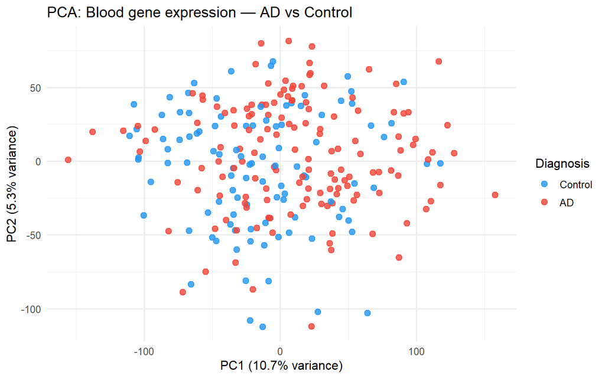

PCA of blood gene expression coloured by diagnosis

```r
pca_res <- prcomp(t(expr_pca), scale. = TRUE)
pca_df  <- data.frame(
  PC1       = pca_res$x[, 1],
  PC2       = pca_res$x[, 2],
  Diagnosis = labels
)

var_exp <- round(100 * pca_res$sdev^2 / sum(pca_res$sdev^2), 1)

ggplot(pca_df, aes(x = PC1, y = PC2, colour = Diagnosis)) +
  geom_point(size = 2.5, alpha = 0.8) +
  scale_colour_manual(values = c("Control" = "#2196F3", "AD" = "#F44336")) +
  theme_minimal(base_size = 12) +
  labs(
    title = "PCA: Blood gene expression — AD vs Control",
    x     = paste0("PC1 (", var_exp[1], "% variance)"),
    y     = paste0("PC2 (", var_exp[2], "% variance)")
  )
```

## 5. Differential expression — identifying candidate genes

Before LASSO, we perform a standard differential expression analysis with `limma` to characterise which genes are altered in AD blood.

```r
design <- model.matrix(~ labels)
fit    <- lmFit(expr_filt, design)
fit    <- eBayes(fit)

# Extract results with FDR correction (Benjamini-Hochberg)
top_genes <- topTable(fit, coef = 2, number = Inf, adjust.method = "BH")

# How many genes pass FDR < 0.05?
n_sig <- sum(top_genes$adj.P.Val < 0.05, na.rm = TRUE)
cat("Genes significant at FDR < 0.05:", n_sig, "\n")
```

```
## Genes significant at FDR < 0.05: 4143
```

```r
head(top_genes[, c("logFC", "AveExpr", "t", "P.Value", "adj.P.Val")], 10)
```

```
##                   logFC   AveExpr         t      P.Value    adj.P.Val
## ILMN_2097421 -0.5662507  9.079016 -12.40512 7.725463e-28 2.220453e-23
## ILMN_1784286 -1.0964396 10.954892 -11.97006 2.187940e-26 3.144288e-22
## ILMN_1695645 -0.3423025  9.538467 -10.89786 7.188763e-23 6.887315e-19
## ILMN_2189936 -0.6900570 12.336881 -10.79458 1.548298e-22 9.184080e-19
## ILMN_1776104 -0.9200810  9.398449 -10.79035 1.597676e-22 9.184080e-19
## ILMN_1732328 -0.9689177 11.024412 -10.73026 2.493603e-22 1.194519e-18
## ILMN_2128128 -0.9935250  9.072732 -10.58035 7.541802e-22 3.096664e-18
## ILMN_2237746 -0.3886275  8.285773 -10.40370 2.758406e-21 9.910264e-18
## ILMN_1792528 -0.6013090 13.732491 -10.36169 3.750456e-21 1.197729e-17
## ILMN_1746516 -0.6505208 13.697633 -10.34458 4.249776e-21 1.221471e-17
```

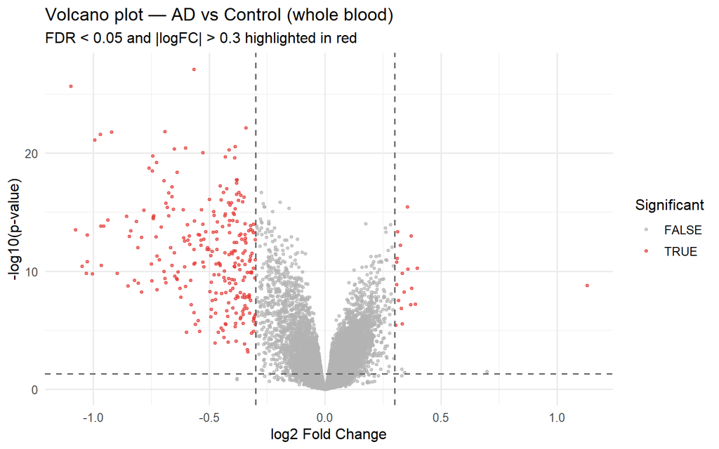

Volcano plot: differential expression AD vs Control

```r
top_genes$Significant <- top_genes$adj.P.Val < 0.05 & abs(top_genes$logFC) > 0.3

ggplot(top_genes, aes(x = logFC, y = -log10(P.Value), colour = Significant)) +
  geom_point(size = 0.8, alpha = 0.6) +
  scale_colour_manual(values = c("FALSE" = "grey70", "TRUE" = "#E53935")) +
  geom_vline(xintercept = c(-0.3, 0.3), linetype = "dashed", colour = "grey40") +
  geom_hline(yintercept = -log10(0.05), linetype = "dashed", colour = "grey40") +
  theme_minimal(base_size = 12) +
  labs(
    title    = "Volcano plot — AD vs Control (whole blood)",
    subtitle = "FDR < 0.05 and |logFC| > 0.3 highlighted in red",
    x        = "log2 Fold Change",
    y        = "-log10(p-value)"
  )
```

## 6. LASSO — biomarker selection

LASSO (Least Absolute Shrinkage and Selection Operator) penalises model complexity by shrinking coefficients of uninformative variables exactly to zero. This achieves simultaneous **variable selection** and regularisation — ideal for high-dimensional biological data where p >> n.

```r
# Use top variable genes as input (reduce dimensionality for LASSO stability)
top_var_probes <- names(sort(probe_var, decreasing = TRUE))[1:2000]
X <- t(expr_filt[top_var_probes, ])   # samples x probes matrix
y <- labels

cat("LASSO input matrix:", dim(X), "\n")
```

```
## LASSO input matrix: 249 2000
```

```r
cat("Class balance:\n")
```

```
## Class balance:
```

```r
print(table(y))
```

```
## y
## Control      AD
##     104     145
```

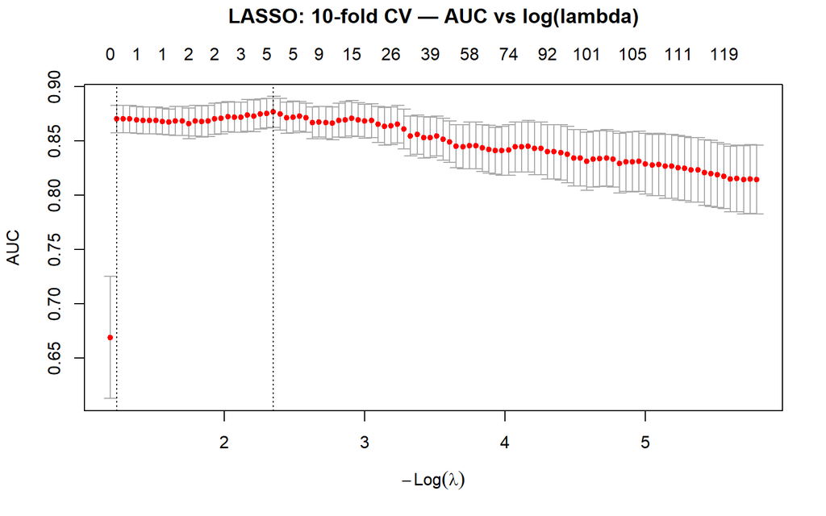

Cross-validation curve for LASSO (alpha=1)

```r
# 10-fold cross-validated LASSO
cv_lasso <- cv.glmnet(
  x        = X,
  y        = y,
  family   = "binomial",
  alpha    = 1,          # alpha=1 → LASSO; alpha=0 → Ridge
  nfolds   = 10,
  type.measure = "auc"
)

plot(cv_lasso)
title("LASSO: 10-fold CV — AUC vs log(lambda)", line = 3)
```

```r
cat("\nBest lambda (min AUC):", round(cv_lasso$lambda.min, 5), "\n")
```

```
##
## Best lambda (min AUC): 0.09527
```

```r
cat("Best lambda (1SE rule):", round(cv_lasso$lambda.1se, 5), "\n")
```

```
## Best lambda (1SE rule): 0.29094
```

```r
# Extract non-zero coefficients at lambda.min
coef_lasso  <- coef(cv_lasso, s = "lambda.min")
selected_idx <- which(coef_lasso[-1, 1] != 0)  # exclude intercept
selected_probes <- rownames(coef_lasso)[-1][selected_idx]
selected_coefs  <- coef_lasso[-1, 1][selected_idx]

cat("Probes selected by LASSO:", length(selected_probes), "\n\n")
```

```
## Probes selected by LASSO: 5
```

```r
lasso_results <- data.frame(
  Probe       = selected_probes,
  Coefficient = round(selected_coefs, 4)
) %>% arrange(desc(abs(Coefficient)))

print(lasso_results)
```

```
##                     Probe Coefficient
## ILMN_2097421 ILMN_2097421     -1.5412
## ILMN_2237746 ILMN_2237746     -0.7035
## ILMN_2189933 ILMN_2189933     -0.1401
## ILMN_2195821 ILMN_2195821      0.0690
## ILMN_2189936 ILMN_2189936     -0.0558
```

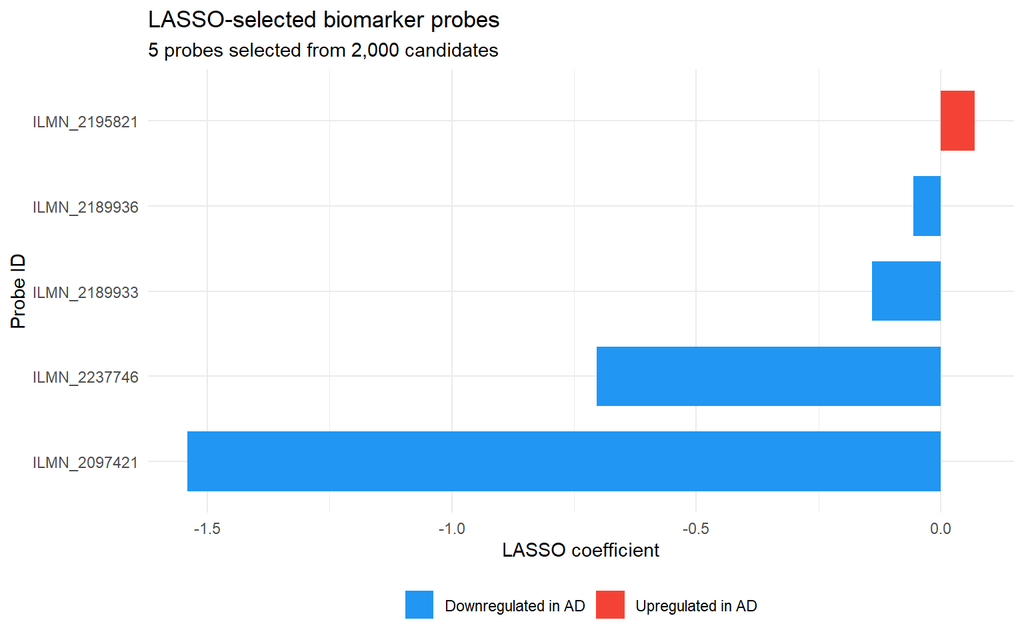

LASSO selected probes and their coefficients

```r
ggplot(lasso_results, aes(x = reorder(Probe, Coefficient), y = Coefficient,
                           fill = Coefficient > 0)) +
  geom_col(width = 0.7) +
  coord_flip() +
  scale_fill_manual(values = c("TRUE" = "#F44336", "FALSE" = "#2196F3"),
                    labels = c("Downregulated in AD", "Upregulated in AD")) +
  theme_minimal(base_size = 11) +
  labs(
    title  = "LASSO-selected biomarker probes",
    subtitle = paste0(length(selected_probes), " probes selected from 2,000 candidates"),
    x      = "Probe ID",
    y      = "LASSO coefficient",
    fill   = NULL
  ) +
  theme(legend.position = "bottom")
```

## 7. Elastic Net comparison

Elastic Net combines LASSO (L1) and Ridge (L2) penalties. It performs better than pure LASSO when predictors are correlated — common in gene expression data.

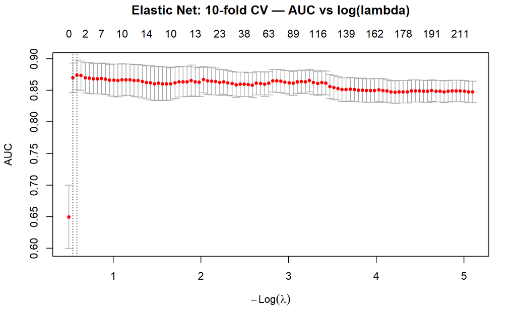

Cross-validation curve for Elastic Net (alpha=0.5)

```r
cv_enet <- cv.glmnet(
  x            = X,
  y            = y,
  family       = "binomial",
  alpha        = 0.5,    # mix of LASSO and Ridge
  nfolds       = 10,
  type.measure = "auc"
)

plot(cv_enet)
title("Elastic Net: 10-fold CV — AUC vs log(lambda)", line = 3)
```

```r
coef_enet    <- coef(cv_enet, s = "lambda.min")
n_enet       <- sum(coef_enet[-1, 1] != 0)
cat("Probes selected by Elastic Net:", n_enet, "\n")
```

```
## Probes selected by Elastic Net: 2
```

```r
cat("Probes selected by LASSO:       ", length(selected_probes), "\n")
```

```
## Probes selected by LASSO:        5
```

## 8. Heatmap of selected biomarkers

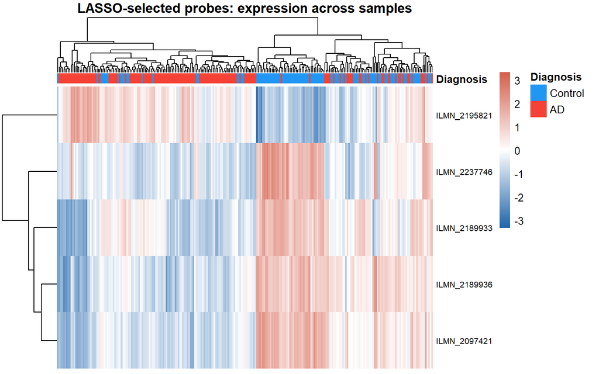

Heatmap of LASSO-selected probes across AD and Control samples

```r
if (length(selected_probes) >= 2) {
  expr_selected <- expr_filt[selected_probes, , drop = FALSE]

  ann_col <- data.frame(Diagnosis = labels)
  rownames(ann_col) <- colnames(expr_selected)

  pheatmap(
    expr_selected,
    annotation_col  = ann_col,
    annotation_colors = list(Diagnosis = c(Control = "#2196F3", AD = "#F44336")),
    show_colnames   = FALSE,
    scale           = "row",
    color           = colorRampPalette(c("#2166AC", "white", "#D6604D"))(100),
    main            = "LASSO-selected probes: expression across samples",
    fontsize_row    = 8
  )
} else {
  cat("Too few probes selected to plot heatmap. Try lambda.1se instead.\n")
}
```

## 9. Summary

| Method | Probes selected | CV AUC (approx.) |
| --- | --- | --- |
| LASSO (α=1) | 5 | See plot above |
| Elastic Net (α=0.5) | 2 | See plot above |